# Packages

R Bootcamp 2021

## Packages

[figure not shown]

Package

## Packages

Packages hold functions and other objects grouped according to theme or purpose described by the DESCRIPTION file.

Examples:

- boot - Bootstrap Functions
- gam - Generalized Additive Models
- forcats - Tools for Working with Categorical Variables (Factors)

## Loading Packages

To load packages in R use `library` or `require`

```r
library(tidyverse)
require(magrittr)
```

## Package Information

- `packageDescription('stats')`

```
## Package: stats
## Version: 4.1.0
## Priority: base
## Title: The R Stats Package
## Author: R Core Team and contributors worldwide
## Maintainer: R Core Team
##       <do-use-Contact-address@r-project.org>
## Contact: R-help mailing list <r-help@r-project.org>
## Description: R statistical functions.
## License: Part of R 4.1.0
## Imports: utils, grDevices, graphics
## Suggests: MASS, Matrix, SuppDists, methods, stats4
## NeedsCompilation: yes
## Built: R 4.1.0; x86_64-w64-mingw32; 2021-05-18
##       08:44:15 UTC; windows
##
## -- File: C:/Program Files/R/R-4.1.0/library/stats/Meta/package.rds
```

## Package Information

- `packageDescription('stats')` for DESCRIPTION information.
- `help(package='stats')` for index page, or
- `package?stats`

```
        Information on package ‘stats’

Description:

Package:            stats
Version:            3.6.3
Priority:           base
Title:              The R Stats Package
Author:             R Core Team and contributors worldwide
Maintainer:         R Core Team <R-core@r-project.org>
Description:        R statistical functions.
License:            Part of R 3.6.3
Imports:            utils, grDevices, graphics
Suggests:           MASS, Matrix, SuppDists, methods, stats4
NeedsCompilation:   yes
Built:              R 3.6.3; x86_64-w64-mingw32; 2020-02-29 09:37:04 UTC;
                    windows
```

## Package Information

- `packageDescription('stats')` for DESCRIPTION information.
- `help(package='stats')` for index page, or
- `package?stats` for the package help page.

```
stats-package              package:stats               R Documentation

The R Stats Package

Description:

     R statistical functions

Details:

     This package contains functions for statistical calculations and
     random number generation.

     For a complete list of functions, use ‘library(help = "stats")’.

Author(s):
     R Core Team and contributors worldwide
     Maintainer: R Core Team <email: R-core@r-project.org>
```

## Namespaces

Packages encapsulate functions and objects together in a Namespace. A namespace is comprised of three layers.

1. **Imports**
   - Functions available inside the package from other packages.
2. **Private**
   - Internal functions, those defined inside the package but only available to other functions in the namespace
3. **Exports**
   - Public interface functions.

## Naming Conflicts

- Namespaces also manage naming conflicts.
- *Example:* `collapse()` function definitions exists in:
  - [`dplyr`](https://www.rdocumentation.org/packages/dplyr/versions/0.7.8/topics/compute)
  - [`ggtree`](https://www.rdocumentation.org/packages/ggtree/versions/1.4.11/topics/collapse)
  - [`nlme`](https://www.rdocumentation.org/packages/nlme/versions/3.1-148/topics/collapse)
  - [`pkgcond`](https://www.rdocumentation.org/packages/pkgcond/versions/0.1.0/topics/collapse)
  - […](https://www.rdocumentation.org/search?q=collapse)

## Search Path

To see what is loaded use `search()`

```r
search()
```

```
##  [1] ".GlobalEnv"        "package:magrittr"
##  [3] "package:printr"    "package:knitr"
##  [5] "package:forcats"   "package:stringr"
##  [7] "package:dplyr"     "package:purrr"
##  [9] "package:readr"     "package:tidyr"
## [11] "package:tibble"    "package:ggplot2"
## [13] "package:tidyverse" "tools:rstudio"
## [15] "package:stats"     "package:graphics"
## [17] "package:grDevices" "package:utils"
## [19] "package:datasets"  "package:methods"
## [21] "Autoloads"         "package:base"
```

## Namespace Specifier

To use a function from a specific package use the `::` operator.  
It may also be used to call a function from a package with loading the package to the search path.

```r
dplyr::last(.leap.seconds)
```

```
## [1] "2017-01-01 GMT"
```

### BONUS: Triple Colon

The `:::` operator breaks encapsulation and retrieves the internal objects of a package, but you will have to know what you are looking for and these functions are rarely documented.

## Finding Packages

[figure not shown]

## Repositories

Repositories are locations where you (and R) can find packages to install and use.

- Structured/Organized
- Typically Online, but can be private.
- Two Major:
  - CRAN
  - BioConductor

## CRAN

[CRAN](https://cran.r-project.org/) stands for: Comprehensive R Archive Network

- The main (and official) repository for contributed R Packages.
- There are currently 17981 packages available on CRAN.
- Low bar to get in.
- Anyone can contribute.

## CRAN:Installing

Most packages will be installed by `install.packages()` function:

```r
# Tools for regression and classification models
install.packages('caret')
```

Most will find it easier to install through RStudio

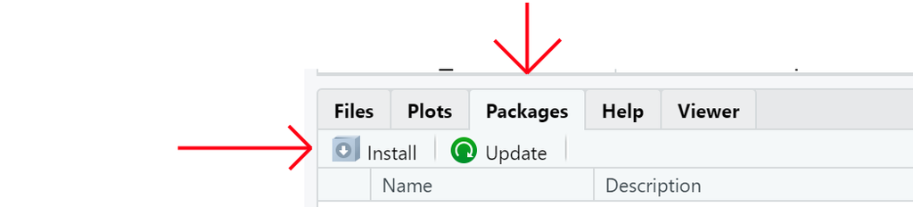

## BioConductor

[BioConductor](http://www.bioconductor.org/)

- Additional Repository specializing in high throughput genomic data packages.
- Much more rigorous to gain entry to.

## BioConductor - Installing

### Prior to R < 4.0.0

```r
source("https://bioconductor.org/biocLite.R")
biocLite()
biocLite("Rgraphviz")
```

### R >= 4.0.0

```r
if (!requireNamespace("BiocManager", quietly = TRUE))
    install.packages("BiocManager")
BiocManager::install(version = "3.11")
BiocManager::install("Rgraphviz")
```

## Github

*Not technicaly a repository*

- Where most new R work in completed.
- Ties in with many other services for things like
  - testing
  - documentation
  - deployment

## Github - installing

For latest development, i.e. pre-release code use the [`devtools`](https://cran.r-project.org/package=devtools) package.

```r
install.packages("devtools")
devtools::install('halpo/pivot')
```

## Managing Packages

- `installed.packages()`
- `remove.package()` ← I don’t think I have *ever* done this.
- `old.packages()`
- `update.packages()`

**Of course all this can be acomplished through RStudio a bit easier.**

## Next Up

**Tidyverse**